# Deliverable 3: Preprocessing

Valentine Hartman

2026-10-15

# Changes Since Deliverable 3

> I have altered my final charts to include all of their original variables rather than only a select few. I now realize that I must consider all the data at my disposal to locate any possible relationships among properties, rather than just focusing on the variables that are the most relevent. As a result, the entire “Selection of Variables” portion from the Data Organization portion of my work from Deliverable 3 has been removed. My processing plan has also been altered to reflect this change, making it much shorter.

> While double-checking my data, I noticed that the total amount of values in IOLPL and the leased properties mentioned in IOLPB do not match. Upon further research into the true nature of the IOLP, I have learned that the Leased properties data subset in my original data refers to the individual lease contracts instead of the properties themselves. To maintain consistancy, I am altering my data to only include the data from IOLPB, which focuses on the properties themselves, giving me a better idea of the distribution of government infrastructure. many of the later mentions of IOLPL have been altered, and my data cleaning plan disregards it. It is still mentioned in the initial overview and descriptions of my data for the sake of providing a complete overview of the raw data.

> In my summary statistics, I altered my charts of property distribution among states and GSA regions to be single histograms that show all the obesrvations, differentiated by color. I also altered the names and titles in the table displaying property distribution among cities.

# Mission Statement

> My ultimate goal for my project is to determine wether or not any patterns exist within the distribution of leased or owned Government Properties within the United States. However, doing so requires the IOLP data to be refined into a more compact state. The following markdown outlines the preprocessing of said data.

# Data Organization & Observations

## Section 1: Presentation of Raw Data

### Overview of Raw Data

> The following block of code contains a preview of the raw data tables I have chosen for my project. While there was also a second data frames containing the dates of each property’s lease, I am mainly focusing on property distribution. Therefore, I only require the first dataset, which contains every property, leased and owned. I have titled this set of data “IOLPB,” which is short for IOLP Buildings. The second data frames only contains leased properties, and has been named “IOLPL,” short for IOLP Leases.

```r
library(tidyr)
library(dplyr)
IOLPB<-read.csv("IOLPBuildings.csv")
head(IOLPB,10)
```

```
##    Location.Code                       Real.Property.Asset.Name
## 1         AK0001            ANCHORAGE HISTORIC FEDERAL BUILDING
## 2         AK0005                     KETCHIKAN FEDERAL BUILDING
## 3         AK0009                           POST OFFICE AND CU H
## 4         AK0013   HURFF A. SAUNDERS FB & ROBERT BOOCHEVER USCH
## 5         AK0029                     FAIRBANKS FEDERAL BUILDING
## 6         AK0031 ANCHORAGE FED. BLDG & JAMES M. FITZGERALD USCH
## 7         AK0032 ANCHORAGE FEDERAL BUILDING US COURTHOUSE ANNEX
## 8         AK0036                      ALCAN RECREATION BUILDING
## 9         AK0037                            ALCAN POLE BUILDING
## 10        AK0038                 POKER CREEK LAND PORT OF ENTRY
##    Installation.Name Owned.or.Leased GSA.Region             Street.Address
## 1  ANCHORAGE FEDERAL           OWNED         10              605 W 4TH AVE
## 2  KETCHIKAN FEDERAL           OWNED         10             648 MISSION ST
## 3                N/A          LEASED         10     2ND ST 112 FEDERAL WAY
```

[output cut: 51 more lines]

```r
IOLPL<-read.csv("IOLPLeases.csv")
head(IOLPL,10)
```

```
##    Location.Code Real.Property.Asset.Name Installation.Name Federal.Leased.Code
## 1         CT3414            2 UNION PLAZA               N/A                   L
## 2         CT3393    HARTFORD SQUARE NORTH               N/A                   L
## 3         CT3425  474-484 BURNSIDE AVENUE               N/A                   L
## 4         CT3467               195 CHURCH               N/A                   L
## 5         CT3466            6 SHAW'S COVE               N/A                   L
## 6         CT3360          LAFAYETTE BLVD.               N/A                   L
## 7         CT3395    AIR EXCHANGE BUILDING               N/A                   L
## 8         CT3460 SALAME PLAZA, BUILDING B               N/A                   L
## 9         CT3462            IRS WATERBURY               N/A                   L
## 10        CT3331      CT FINANCIAL CENTER               N/A                   L
##    GSA.Region                 Street.Address          City State Zip.Code
## 1           1                    2 UNION PLZ    NEW LONDON    CT     6320
## 2           1               10 COLUMBUS BLVD      HARTFORD    CT     6106
## 3           1        474-484 BURNSIDE AVENUE EAST HARTFORD    CT     6108
```

[output cut: 40 more lines]

### Chart Dimensions

> IOLPB: 7,758 observations, 18 variables

> IOLPL: 7,074 observations, 19 variables

### Data Dictionary

> The following “data dictionary” serves as an overview of each variable in the data, and provides the following:
> 1. The variable’s name.
> 2. A brief description of the variable and its contents.
> 3. Which of the two data-sets the variable is in (“IOLPB” or “IOLPL”).
> 4. The data type of the variable (categorical or numerical).

> **NOTE:** Descriptions of the data can also be found on the website that I pulled the data from.

> [Source of data and overview of the variables within it](https://catalog.data.gov/dataset/inventory-of-owned-and-leased-properties-iolp)

#### “Location.Code”

> This variable contains location codes, the GSA’s method for identifying each property.

> This variable is present in: IOLPB, IOLPL

> Variable Type: Categorial

#### “Real.Property.Asset.Name”

> This variable contains the name of each property. It was made with the intent of aiding viewers of the data in locating information on specific properties. A handfull of the values within this variable match their observations’s entry in the “Street.Address” variable.

> This variable is present in: IOLPB, IOLPL

> Variable type: Categorical

#### “Installation.Name”

> This variable primarily consists of N/A values. The few values that it does list are meant to group together properties that are parts of specific instilations.

> This variable is present in: IOLPB, IOLPL

> Variable type: Categorical

#### “Owned.or.Leased”

> This variable seperates leased and owned properties. Its entries are all either “OWNED” or “LEASED.” This data will be invaluable for determining the distribution of the two types of property across the United States.

> This variable is present in: IOLPB

> Variable type: Categorical

#### “GSA.Region”

> The GSA, the administration that curates the IOLP and locates property for government use, divides the acuisition and management of various properties among 11 districts, with each one encompassing different states. This variable organizes properties into districts using a number associated with each district.

> This variable is present in: IOLPB, IOLPL

> Variable type: Functionally categorical, yet displayed as numerical.

#### “Street.Address”

> This variable contains the street adress of the properties in the address. Some of the entries in this variable correspond with their observations’s value in the “Real.Property.Asset.Name” variable.

> This variable is present in: IOLPB, IOLPL

> Variable type: Categorical

#### “City”

> This variable contains the name of the city that each property is located in.

> This variable is present in: IOLPB, IOLPL

> Variable type: Categorical

#### “State”

> This variable contains an abbreviation of the state or territory that houses each property.

> This variable is present in: IOLPB, IOLPL

> Variable type: Categorical

#### “Zip.Code”

> This variable contains each property’s zip code.

> This variable is present in: IOLPB, IOLPL

#### “Latitude”

> This variable contains the y-value of the property on the global coordinate grid.

> This variable is present in: IOLPB, IOLPL

> Variable type: Numerical

#### “Longitude”

> This variable contains the x-value of the property on the global coordinate grid.

> This variable is present in: IOLPB, IOLPL

> Variable type: Numerical

#### “Building.Rentable.Square.Feet”

> This variable displays the total rentable area of each property in square feet.

> This variable is present in: IOLPB, IOLPL

> Variable type: Numerical

#### “Available.Square.Feet”

> This variable displays the total amount of vacant square footage within a building.

> This variable is present in: IOLPB, IOLPL

> Variable type: Numerical

#### “Construction.Date”

> This variable lists the year that each property was built.

> This variable is present in: IOLPB

> Variable type: Numerical

#### “Congressional.District”

> This variable contains the congressional district each property is located within.

> This variable is present in: IOLPB, IOLPL

> Variable type: Numerical

#### “Congressional.District.Representative.Name”

> This variable contains the name of the representative in charge of the congressional district that each property is located in.

> This variable is present in: IOLPB, IOLPL

> Variable type: Categorical

#### “Building.Status”

> This variable indicates wether or not the property is actively in use.

> This variable is present in: IOLPB

> Variable type: Categorical

#### “Real.Property.Asset.Type”

> This variable displays what kind of asset is housed on each property.

> This variable is present in: IOLPB, IOLPL

> Variable type: Categorical

#### “Lease.Number”

> This variable houses the codes used by the GSA to identify each lease.

> This variable is present in: IOLPL

> Variable type: Numerical

#### “Lease.Effective.Date”

> This variable houses the date that the lease of each leased property was established.

> This variable is present in: IOLPL

> Variable type: Numerical

#### “Lease.Expiration.Date”

> This variable houses the date that the lease of each leased property expires.

> This variable is present in: IOLPL

> Variable type: Numerical

### Raw Data Cleanliness Assessment

> The current state of the data seems somewhat well organized. Every property has a corresponding coordinate grid entry and state, which are the two main variables I had in mind when initially designing my project. However, many of the more specific variables, such as the values within the “Congressional.District.Representatives.Name” and “Instillation.Name” variables seem to primarily consist of N/A values. This makes sense, as not all properties are part of specific instillations.

> Certain variables also seem to contain high levels of repitition. For example, every ovservation of the “Real.Property.Asset.Type” variable is a building, and every property is labled “active” according to the “Building.Status” variable. While variables like this display valid information and have obvious purposes, they will not necisarily help me inderstand the general concentration of properties.

> Thankfully, as my project mainly focuses on the general distribution of the properties within the IOLP, I will not need variables regarding finer details or specific identification.

## Section 2: Filtration of Data

### Processing plan

> While cleaning my data, I will need to remove certain observations from both charts, as some of the properties listed in the IOLP lie outside of the United States, and are therefore irrelevant to my final results. Furthermore, However, since Washington DC counts as a U.S. territory, I will leave it, as it still lies within the main United States.

> As for the data frames themselves, I will primarily be using IOLPB for future maps, as it contains all the properties. IOLPL concerns includes individual lease agreements, therefore having more entries than the proper amount of leased properties mentioned in IOLPB. IOLPB will be split into three charts; One containing all properties, one containing leased properties, and one containing owned properties. After that, I can simplify the data into as many smaller tables as I deem nessecary to properly compare data.

### Code

```r
IOLPBUS<-IOLPB%>%filter(State!="AS"&State!="GU"&State!="MP"&State!="PR"&State!="VI"&State!="CU")
```

#### Final Seperation and Naming of Data Frames

```r
IOLP.all<-IOLPBUS
IOLP.owned<-(IOLPBUS%>%filter(Owned.or.Leased=="OWNED")%>%select(-Owned.or.Leased))
IOLP.leased<-(IOLPBUS%>%filter(Owned.or.Leased=="LEASED")%>%select(-Owned.or.Leased))
head(IOLP.all,10)
```

```
##    Location.Code                       Real.Property.Asset.Name
## 1         AK0001            ANCHORAGE HISTORIC FEDERAL BUILDING
## 2         AK0005                     KETCHIKAN FEDERAL BUILDING
## 3         AK0009                           POST OFFICE AND CU H
## 4         AK0013   HURFF A. SAUNDERS FB & ROBERT BOOCHEVER USCH
## 5         AK0029                     FAIRBANKS FEDERAL BUILDING
## 6         AK0031 ANCHORAGE FED. BLDG & JAMES M. FITZGERALD USCH
## 7         AK0032 ANCHORAGE FEDERAL BUILDING US COURTHOUSE ANNEX
## 8         AK0036                      ALCAN RECREATION BUILDING
## 9         AK0037                            ALCAN POLE BUILDING
## 10        AK0038                 POKER CREEK LAND PORT OF ENTRY
##    Installation.Name Owned.or.Leased GSA.Region             Street.Address
## 1  ANCHORAGE FEDERAL           OWNED         10              605 W 4TH AVE
## 2  KETCHIKAN FEDERAL           OWNED         10             648 MISSION ST
## 3                N/A          LEASED         10     2ND ST 112 FEDERAL WAY
```

[output cut: 51 more lines]

```r
head(IOLP.owned,10)
```

```
##    Location.Code                       Real.Property.Asset.Name
## 1         AK0001            ANCHORAGE HISTORIC FEDERAL BUILDING
## 2         AK0005                     KETCHIKAN FEDERAL BUILDING
## 3         AK0013   HURFF A. SAUNDERS FB & ROBERT BOOCHEVER USCH
## 4         AK0029                     FAIRBANKS FEDERAL BUILDING
## 5         AK0031 ANCHORAGE FED. BLDG & JAMES M. FITZGERALD USCH
## 6         AK0032 ANCHORAGE FEDERAL BUILDING US COURTHOUSE ANNEX
## 7         AK0036                      ALCAN RECREATION BUILDING
## 8         AK0037                            ALCAN POLE BUILDING
## 9         AK0038                 POKER CREEK LAND PORT OF ENTRY
## 10        AK0040                               ALCAN LAND LEASE
##    Installation.Name GSA.Region             Street.Address      City State
## 1  ANCHORAGE FEDERAL         10              605 W 4TH AVE ANCHORAGE    AK
## 2  KETCHIKAN FEDERAL         10             648 MISSION ST KETCHIKAN    AK
## 3                N/A         10  709 W 9TH ST FB/USPO/USCH    JUNEAU    AK
```

[output cut: 51 more lines]

```r
head(IOLP.leased,10)
```

```
##    Location.Code       Real.Property.Asset.Name Installation.Name GSA.Region
## 1         AK0009           POST OFFICE AND CU H               N/A         10
## 2         AK3139                 TROUTTE CENTER               N/A         10
## 3         AK3166                 PETERSON TOWER               N/A         10
## 4         AK3177           TUDOR BUSINESS CNTER               N/A         10
## 5         AK3180               MICHAEL BUILDING               N/A         10
## 6         AK3219                 RHINE BUILDING               N/A         10
## 7         AK3227 ELIZABETH PERATROVICH BUILDING               N/A         10
## 8         AK3228                     K & R BLDG               N/A         10
## 9         AK3237           VECO ALASKA BUILDING               N/A         10
## 10        AK3239 ALASKA PACIFIC UNIV.GRACE HALL               N/A         10
##            Street.Address       City State Zip.Code Latitude Longitude
## 1  2ND ST 112 FEDERAL WAY   WRANGELL    AK    99929 56.47395 -132.3881
## 2           329 HARBOR DR      SITKA    AK    99835 57.05028 -135.3336
## 3                510 L ST  ANCHORAGE    AK    99501 61.21715 -149.9043
```

[output cut: 40 more lines]

### Final Chart Dimensions

IOLP.all: 7,659 observations, 18 variables IOLP.leased: 5,989 observations, 17 variables IOLP.owned: 1,670 observations, 17 variables

## Section 3: Observations of Refined Data

### Summary Statistics

> The following chart displays the distributions of properties among states, both owned and leased. Due to the odd formatting that resulted from the quantity of states, the charts have been made interactive for easier viewing.

```r
library(ggplot2)
library(plotly)
options(scipen = 999)
statesbar.all<-IOLP.all%>%group_by(State)%>%summarise(Property.Density=n())%>%arrange(-Property.Density)%>%mutate(state = State)



IOLP.all.and.Statesbars<-full_join(IOLP.all, statesbar.all, by = "State")

propdist<-(ggplot(IOLP.all.and.Statesbars) +
geom_bar(aes(x = State, fill = Owned.or.Leased))+scale_fill_manual(values = c(
"LEASED" = "blue","OWNED" = "orange"))+coord_flip()+labs(x="State", y="Government Properties", title="Total Property Distribution Among States"))

ggplotly(propdist)
```

[interactive chart not shown]

> In the following table, I located the quantity of total properties within certain cities, as well as what percentage of total property is within each city. Due to the large quantity of cities in the IOLP, I have presented the information in a table rather than a graph. Should the distribution of properties among states prove to be too underwhelming, this should allow me to notice whether or not any patterns exist in the distributions of government properties among cities, as larger cities in specific states may possess particularily large amounts of property.

> Unlike the previous graph, I have calculated seperate visuals for total property, owned property, and leased property.

> Due to the very large number of cities within the IOLP, I have arranged them into tables.

```r
IOLP.all.city<-IOLP.all%>%group_by(City)%>%summarize(Total.Property.Density=n())%>%arrange(-Total.Property.Density)%>%mutate(precent=(((Total.Property.Density/(sum(Total.Property.Density)))*100)))%>%mutate(percent=round(precent,2))%>%select(City,Total.Property.Density,percent)
head(IOLP.all.city,10)
```

```
## # A tibble: 10 × 3
##    City        Total.Property.Density percent
##    <chr>                        <int>   <dbl>
##  1 WASHINGTON                     378    4.94
##  2 EL PASO                         67    0.87
##  3 LAREDO                          67    0.87
##  4 HOUSTON                         58    0.76
##  5 SAN DIEGO                       58    0.76
##  6 ATLANTA                         53    0.69
##  7 LAKEWOOD                        52    0.68
##  8 COLUMBUS                        51    0.67
##  9 CHICAGO                         49    0.64
## 10 SPRINGFIELD                     49    0.64
```

```r
IOLP.leased.city<-IOLP.leased%>%group_by(City)%>%summarize(Leased.Property.Density=n())%>%arrange(-Leased.Property.Density)%>%mutate(precent=(((Leased.Property.Density/(sum(Leased.Property.Density)))*100)))%>%mutate(percent=round(precent,2))%>%select(City,Leased.Property.Density,percent)
head(IOLP.leased.city,10)
```

```
## # A tibble: 10 × 3
##    City        Leased.Property.Density percent
##    <chr>                         <int>   <dbl>
##  1 WASHINGTON                       89    1.49
##  2 HOUSTON                          51    0.85
##  3 SPRINGFIELD                      47    0.78
##  4 ATLANTA                          46    0.77
##  5 ARLINGTON                        44    0.73
##  6 SAN ANTONIO                      42    0.7
##  7 SAN DIEGO                        41    0.68
##  8 KANSAS CITY                      37    0.62
##  9 PORTLAND                         36    0.6
## 10 COLUMBUS                         35    0.58
```

```r
IOLP.owned.city<-IOLP.owned%>%group_by(City)%>%summarize(Owned.Property.Density=n())%>%arrange(-Owned.Property.Density)%>%mutate(precent=(((Owned.Property.Density/(sum(Owned.Property.Density)))*100)))%>%mutate(percent=round(precent,2))%>%select(City,Owned.Property.Density,percent)
head(IOLP.owned.city,10)
```

```
## # A tibble: 10 × 3
##    City           Owned.Property.Density percent
##    <chr>                           <int>   <dbl>
##  1 WASHINGTON                        289   17.3
##  2 LAREDO                             50    2.99
##  3 EL PASO                            38    2.28
##  4 LAKEWOOD                           36    2.16
##  5 SILVER SPRING                      29    1.74
##  6 BROWNSVILLE                        26    1.56
##  7 BETHESDA                           23    1.38
##  8 ST. LOUIS                          22    1.32
##  9 DEL RIO                            21    1.26
## 10 JEFFERSONVILLE                     21    1.26
```

```r
Distribution.GSA<-IOLP.all%>%group_by(GSA.Region)%>%summarize(Property.Density=n())%>%arrange(-GSA.Region)
IOLP.all.and.GSA<-full_join(IOLP.all, Distribution.GSA, by = "GSA.Region")

ggplotly(ggplot(IOLP.all.and.GSA)+geom_bar(aes(x=GSA.Region,fill=Owned.or.Leased))+scale_fill_manual(values = c(
"LEASED" = "blue","OWNED" = "orange"))+labs(x="GSA Region", y="Properties Within Region", title="GSA Property Distribution Among Its Regions (all)"))
```

[interactive chart not shown]

# Discussion

> My next primary goal is still the creation of maps. I plan to use the “Leaflet” package to create maps to display the differences in the distribution of all properties in the IOLP, the leased properties, and the owned properties. However, I will also use the City and GSA region variables to look for further comparisons in the data, and figure out if the size of GSA regions has anything to do with the amount of cities, states, or properties within a certain area. This data will not only open up opportunities for future research, but also theoretically allow the GSA and federal government to look through the density of their properties and decide wether or not they lack or have an excess of infrastructure in specific locations Furthermore, during the creation of these maps, I may have to remove DC from the properties considered in it, as the values associated with DC may be improperly processed during map creation. This shouldn’t be too consequential, as I can already the reasoning behind the property distribution in DC. Furthermore, I can still include it in a map displaying scattered points.

# Exploratory Data Visualizations

## Property Distribution Among States

```r
ggplotly(propdist)
```

[interactive chart not shown]

> While this chart has been pulled from my deliverable 3 submission, it does a good job of displaying the proper property distribution across states. Seemingly, DC has the most owned property, while Texas and California have the most total property. While DC’s density of owned property is likely due to its status as the capital, I have reason to believe that the density of property in California and Texas may be related to the extensive population of both states, as the two states are the most densely populated in America.

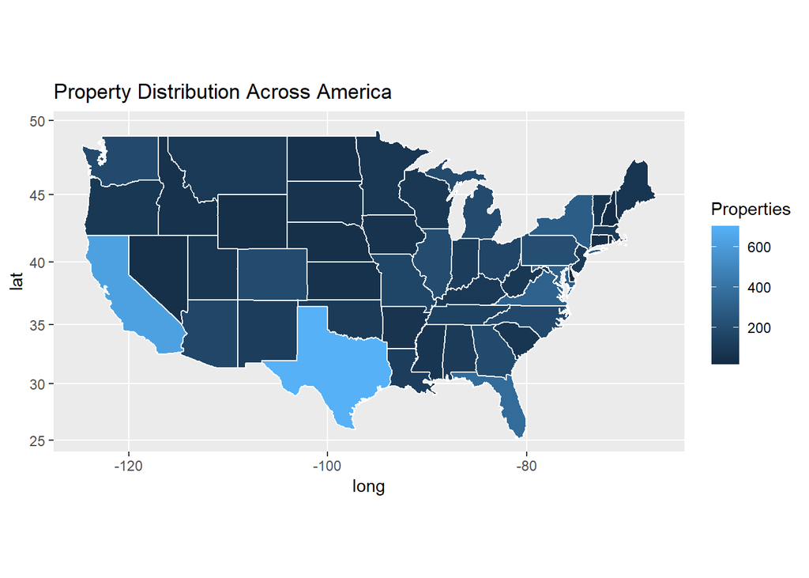

```r
library(ggplot2)
state_counts <- IOLP.all %>%
count(State, name = "properties") %>%
mutate(region = tolower(state.name[match(State, state.abb)]))

state_shape <- map_data("state") %>%
left_join(state_counts, by = "region")

ggplot(state_shape, aes(x = long, y = lat, group = group, fill = properties)) +
geom_polygon(color = "white") +
coord_map() +
labs(title = "Property Distribution Across America", fill = "Properties")
```

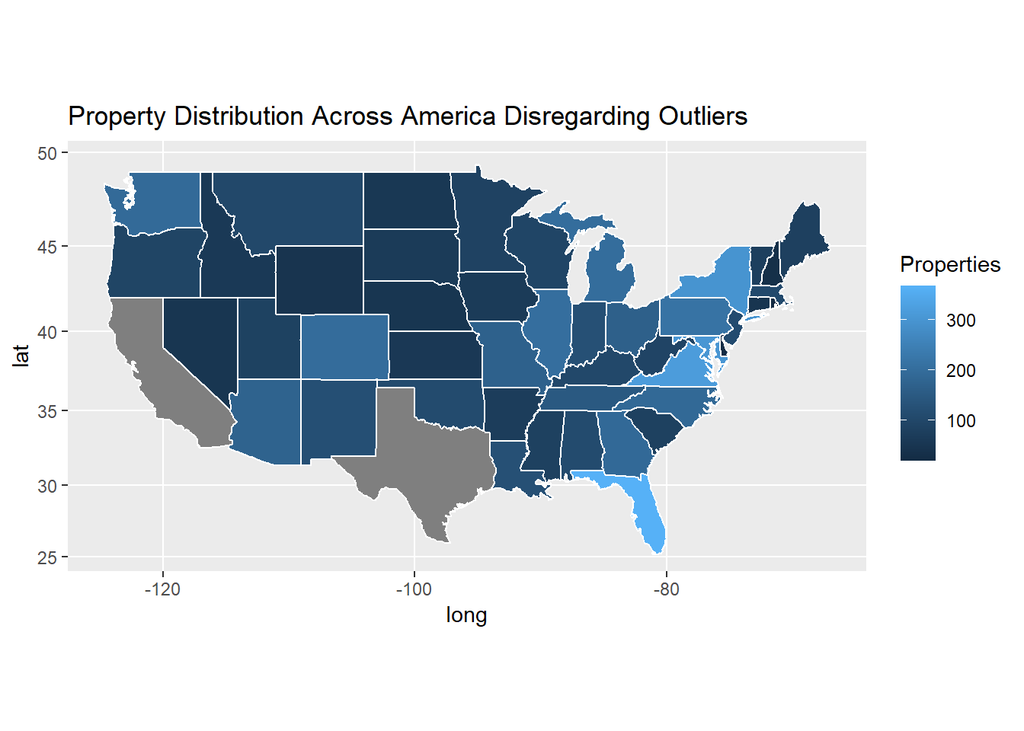

```r
state_countsB <- IOLP.all %>%
count(State, name = "properties") %>% filter(State!="CA"&State!="TX"&State!="DC")%>%
mutate(region = tolower(state.name[match(State, state.abb)]))

state_shapeB <- map_data("state") %>%
left_join(state_countsB, by = "region")

ggplot(state_shapeB, aes(x = long, y = lat, group = group, fill = properties)) +
geom_polygon(color = "white") +
coord_map() +
labs(title = "Property Distribution Across America Disregarding Outliers", fill = "Properties")
```

>The map shown is a simple comparison of latitude and longitute in relation to the total property within each state. The first chart shows the total property distribution across the country by state. However, I realized that the appearence of the chart was skewed by the sheer density of property in Texas and California. The second chart shows the concentration of properties in other states, without the gradient being skewed by the presence of Texas or California.

> I created this chart to get an idea of the general distribution of properties. I now see that there is a slight concentration of properties in the Eastern United states, closer to the capital. However, I also believe that the small size, close proximity, and general age of the Eastern States may have something to do with this concentration.